# Notebook

## Project Overview

```python
!pip install -q catboost xgboost lightgbm

import numpy as np
import pandas as pd
import matplotlib.pyplot as plt
import seaborn as sns
import math

from sklearn.model_selection import KFold, cross_val_score, learning_curve, train_test_split
from sklearn.preprocessing import StandardScaler, LabelEncoder
from sklearn.metrics import mean_squared_error, r2_score

from sklearn.linear_model import LinearRegression, Ridge, Lasso, ElasticNet, BayesianRidge
from sklearn.ensemble import RandomForestRegressor, GradientBoostingRegressor, ExtraTreesRegressor
from sklearn.svm import SVR

from xgboost import XGBRegressor
from catboost import CatBoostRegressor
from lightgbm import LGBMRegressor

from sklearn.inspection import permutation_importance

import joblib
import warnings
warnings.filterwarnings("ignore")

from google.colab import files
import io
sns.set()
```

## Dataset Overview

The dataset contains a mix of academic, behavioral, and demographic features related to undergraduate students.  
Key variables include:

- Study habits (study hours, library usage, sleep hours)
- Work and financial factors (work hours, scholarship status, financial support)
- Stress and well-being indicators (stress level, homesickness level, social support score)
- Academic history (attendance percentage, previous semester GPA)
- Demographic details (age, country/region, years in the US, visa type)

Our target variable is **GPA**, which we aim to predict using regression models.

```python
df = pd.read_csv('/content/Students_Dataset.csv')
df.head()
```

|  | gender | parental level of education | age | country_region | years_in_us | family_income_usd | financial_support | work_hours_per_week | scholarship_status | housing_type | ... | library_usage_hours | stress_level | homesickness_level | academic_pressure | social_support_score | visa_type | work_restriction_impact | prev_sem_gpa | english_proficiency_score | semester_gpa |
| --- | --- | --- | --- | --- | --- | --- | --- | --- | --- | --- | --- | --- | --- | --- | --- | --- | --- | --- | --- | --- | --- |
| 0 | female | bachelor's degree | 24.0 | Other | 4.0 | 131193.0 | Scholarship | 16.0 | Yes | Off-campus | ... | 9.7 | 8.0 | 9.0 | 7.0 | 9.0 | F1 | 10.0 | 3.60 | 81.8 | 2.5474 |
| 1 | female | some college | 21.0 | Nigeria | 4.0 | 23471.0 | Loan | 2.0 | Yes | Off-campus | ... | 5.3 | 10.0 | 7.0 | 10.0 | 3.0 | F1 | 2.0 | 3.57 | 103.6 | 3.3692 |
| 2 | female | master's degree | 28.0 | Germany | 3.0 | 127332.0 | Loan | 25.0 | No | On-campus | ... | 13.8 | 2.0 | 10.0 | 6.0 | 1.0 | J1 | 5.0 | 2.73 | 108.9 | 2.5860 |
| 3 | male | associate's degree | 25.0 | South Korea | 1.0 | 140312.0 | Self-funded | 14.0 | No | Off-campus | ... | 2.0 | 9.0 | 8.0 | 10.0 | 1.0 | F1 | 1.0 | 3.98 | 110.9 | 2.0678 |
| 4 | male | some college | 22.0 | Germany | 4.0 | 143379.0 | Loan | 3.0 | No | With relatives | ... | 10.1 | 3.0 | 6.0 | 4.0 | 7.0 | F1 | 9.0 | 3.19 | 86.0 | 2.9862 |

5 rows × 25 columns

## Exploratory Data Analysis (EDA)

We explore the distributions of numerical features to understand patterns, variability, and potential outliers in the dataset.

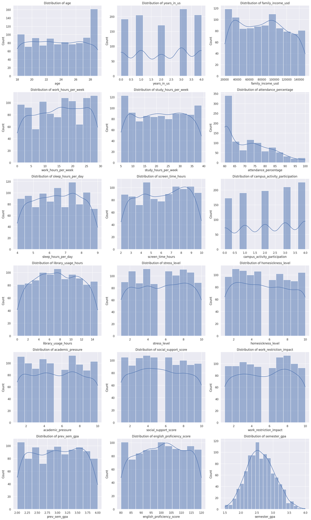

```python
num_cols = df.select_dtypes(include=['int64', 'float64']).columns

n_cols = 3
n_rows = math.ceil(len(num_cols) / n_cols)

plt.figure(figsize=(18, 5 * n_rows))

for i, col in enumerate(num_cols, 1):
    plt.subplot(n_rows, n_cols, i)
    sns.histplot(df[col], kde=True)
    plt.title(f"Distribution of {col}")

plt.tight_layout()
plt.show()
```

## Correlation Analysis

We compute feature correlations to identify which factors are most strongly associated with semester GPA.

```python
corr = df.corr(numeric_only=True)['semester_gpa'].sort_values(ascending=False)
corr
```

|  | semester_gpa |
| --- | --- |
| semester_gpa | 1.000000 |
| study_hours_per_week | 0.608145 |
| attendance_percentage | 0.323327 |
| sleep_hours_per_day | 0.138785 |
| social_support_score | 0.120518 |
| years_in_us | 0.064348 |
| prev_sem_gpa | 0.026875 |
| campus_activity_participation | 0.020235 |
| english_proficiency_score | 0.018899 |
| family_income_usd | 0.002438 |
| library_usage_hours | -0.003221 |
| screen_time_hours | -0.011018 |
| work_restriction_impact | -0.011363 |
| age | -0.015058 |
| homesickness_level | -0.145748 |
| stress_level | -0.148931 |
| academic_pressure | -0.206254 |
| work_hours_per_week | -0.526183 |

**dtype:** float64

[figure not shown]

```python
top10 = corr.head(10)
plt.figure(figsize=(10, 5))
plt.bar(top10.index, top10.values)
plt.xticks(rotation=45, ha='right')
plt.ylabel("Correlation Value")
plt.title("Top 10 Strongest Feature Correlations")
plt.tight_layout()
plt.show()
```

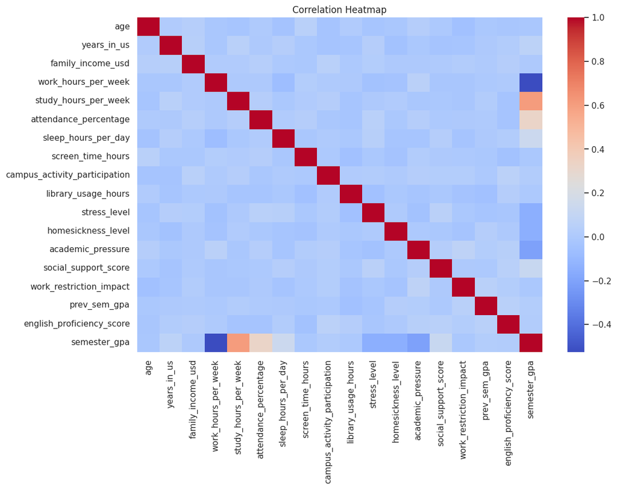

```python
plt.figure(figsize=(12, 8))
sns.heatmap(df.corr(numeric_only=True), cmap='coolwarm', annot=False)
plt.title("Correlation Heatmap")
plt.xticks(rotation=90)
plt.yticks(rotation=0)
plt.show()
```

## Data Preprocessing

We encode categorical features and scale numerical features before training the models.

```python
cat_cols = df.select_dtypes(include=["object"]).columns

encoders = {}
for col in cat_cols:
    le = LabelEncoder()
    df[col] = le.fit_transform(df[col])
    encoders[col] = le

df.head()
```

|  | gender | parental level of education | age | country_region | years_in_us | family_income_usd | financial_support | work_hours_per_week | scholarship_status | housing_type | ... | library_usage_hours | stress_level | homesickness_level | academic_pressure | social_support_score | visa_type | work_restriction_impact | prev_sem_gpa | english_proficiency_score | semester_gpa |
| --- | --- | --- | --- | --- | --- | --- | --- | --- | --- | --- | --- | --- | --- | --- | --- | --- | --- | --- | --- | --- | --- |
| 0 | 0 | 1 | 24.0 | 5 | 4.0 | 131193.0 | 2 | 16.0 | 1 | 0 | ... | 9.7 | 8.0 | 9.0 | 7.0 | 9.0 | 0 | 10.0 | 3.60 | 81.8 | 2.5474 |
| 1 | 0 | 4 | 21.0 | 4 | 4.0 | 23471.0 | 1 | 2.0 | 1 | 0 | ... | 5.3 | 10.0 | 7.0 | 10.0 | 3.0 | 0 | 2.0 | 3.57 | 103.6 | 3.3692 |
| 2 | 0 | 3 | 28.0 | 2 | 3.0 | 127332.0 | 1 | 25.0 | 0 | 1 | ... | 13.8 | 2.0 | 10.0 | 6.0 | 1.0 | 1 | 5.0 | 2.73 | 108.9 | 2.5860 |
| 3 | 1 | 0 | 25.0 | 6 | 1.0 | 140312.0 | 3 | 14.0 | 0 | 0 | ... | 2.0 | 9.0 | 8.0 | 10.0 | 1.0 | 0 | 1.0 | 3.98 | 110.9 | 2.0678 |
| 4 | 1 | 4 | 22.0 | 2 | 4.0 | 143379.0 | 1 | 3.0 | 0 | 2 | ... | 10.1 | 3.0 | 6.0 | 4.0 | 7.0 | 0 | 9.0 | 3.19 | 86.0 | 2.9862 |

5 rows × 25 columns

```python
target = "semester_gpa"
X = df.drop(columns=[target])
y = df[target]

feature_names = X.columns.tolist()

scaler = StandardScaler()
X_scaled = scaler.fit_transform(X)
```

```python
models = {
    "LinearRegression": LinearRegression(),
    "Ridge": Ridge(alpha=1.0),
    "Lasso": Lasso(alpha=0.01),
    "ElasticNet": ElasticNet(alpha=0.01, l1_ratio=0.5),
    "BayesianRidge": BayesianRidge(),
    "RandomForest": RandomForestRegressor(n_estimators=300, random_state=42),
    "ExtraTrees": ExtraTreesRegressor(n_estimators=300, random_state=42),
    "GradientBoosting": GradientBoostingRegressor(),
    "SVR": SVR(),
    "XGBoost": XGBRegressor(objective='reg:squarederror', n_estimators=300, random_state=42),
    "CatBoost": CatBoostRegressor(verbose=0, random_state=42),
    "LGBM": LGBMRegressor(random_state=42),
}
```

```python
kf = KFold(n_splits=5, shuffle=True, random_state=42)

cv_results = {}

for name, model in models.items():
    r2_scores = cross_val_score(model, X_scaled, y, cv=kf, scoring="r2")
    rmse_scores = -cross_val_score(model, X_scaled, y, cv=kf, scoring="neg_root_mean_squared_error")
    cv_results[name] = {
        "cv_r2_mean": r2_scores.mean(),
        "cv_r2_std": r2_scores.std(),
        "cv_rmse_mean": rmse_scores.mean(),
        "cv_rmse_std": rmse_scores.std()
    }

cv_df = pd.DataFrame(cv_results).T.sort_values("cv_rmse_mean")
cv_df
```

[output not shown]

[output cut: 450 more lines]

[output not shown]

|  | cv_r2_mean | cv_r2_std | cv_rmse_mean | cv_rmse_std |
| --- | --- | --- | --- | --- |
| ElasticNet | 0.862543 | 0.022227 | 0.159492 | 0.006900 |
| BayesianRidge | 0.861402 | 0.023655 | 0.160069 | 0.007474 |
| Ridge | 0.861392 | 0.023701 | 0.160072 | 0.007538 |
| LinearRegression | 0.861380 | 0.023717 | 0.160078 | 0.007562 |
| Lasso | 0.859497 | 0.022104 | 0.161298 | 0.006902 |
| CatBoost | 0.831629 | 0.025356 | 0.176606 | 0.005868 |
| GradientBoosting | 0.815735 | 0.029181 | 0.184549 | 0.007243 |
| LGBM | 0.804853 | 0.039752 | 0.189538 | 0.012594 |
| SVR | 0.804943 | 0.030064 | 0.190058 | 0.009397 |
| ExtraTrees | 0.768314 | 0.039607 | 0.206947 | 0.009749 |
| XGBoost | 0.767666 | 0.036202 | 0.207494 | 0.010394 |
| RandomForest | 0.750280 | 0.044029 | 0.214780 | 0.010816 |

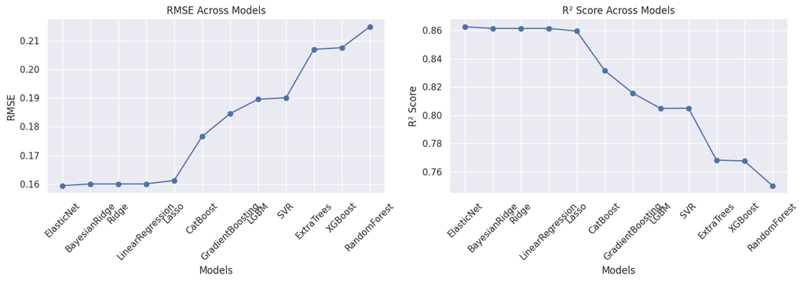

```python
plt.figure(figsize=(14, 5))

plt.subplot(1, 2, 1)
plt.plot(cv_df.index, cv_df["cv_rmse_mean"], marker='o')
plt.title("RMSE Across Models")
plt.xlabel("Models")
plt.ylabel("RMSE")
plt.xticks(rotation=45)
plt.grid(True)

plt.subplot(1, 2, 2)
plt.plot(cv_df.index, cv_df["cv_r2_mean"], marker='o')
plt.title("R² Score Across Models")
plt.xlabel("Models")
plt.ylabel("R² Score")
plt.xticks(rotation=45)
plt.grid(True)

plt.tight_layout()
plt.show()
```

## Selecting and Training the Best Model

Based on cross-validation performance, the model with the lowest RMSE is selected as the final model.  
We now train this best model on the training set and evaluate it on the test set to measure real-world performance.

```python
best_model_name = cv_df.index[0]
best_model_name
```

```
'ElasticNet'
```

```python
best_model = models[best_model_name]
best_model
```

```
ElasticNet(alpha=0.01)
```

```python
X_train, X_test, y_train, y_test = train_test_split(
    X_scaled, y, test_size=0.25, random_state=42
)

best_model.fit(X_train, y_train)
y_pred = best_model.predict(X_test)

final_rmse = np.sqrt(mean_squared_error(y_test, y_pred))
final_r2 = r2_score(y_test, y_pred)

final_rmse, final_r2
```

```
(np.float64(0.15255748623383955), 0.8798280084633119)
```

## True vs Predicted GPA

The plot below compares the model’s predicted GPA values with the actual GPA values from the test set.  
A strong alignment along the diagonal line indicates good predictive performance.

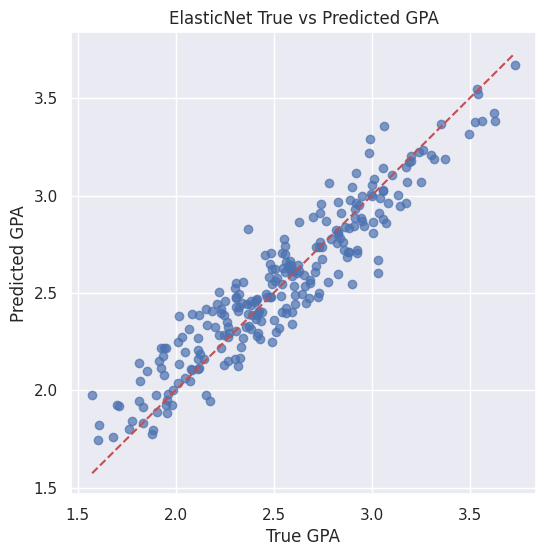

```python
plt.figure(figsize=(6,6))
plt.scatter(y_test, y_pred, alpha=0.7)
min_val = min(y_test.min(), y_pred.min())
max_val = max(y_test.max(), y_pred.max())
plt.plot([min_val, max_val], [min_val, max_val], 'r--')
plt.xlabel("True GPA")
plt.ylabel("Predicted GPA")
plt.title(f"{best_model_name} True vs Predicted GPA")
plt.show()
```

## Residuals vs Predicted GPA

This plot shows how prediction errors (residuals) vary across predicted GPA values.  
A random scatter around zero suggests that the model captures the underlying pattern well without systematic bias.

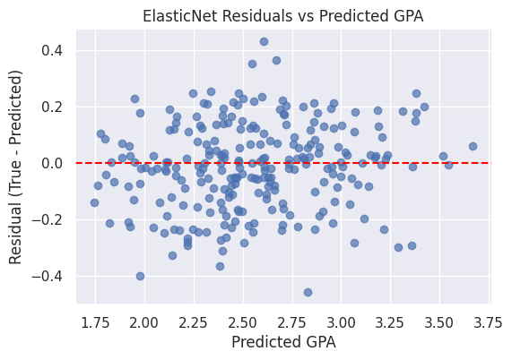

```python
residuals = y_test - y_pred

plt.figure(figsize=(6,4))
plt.scatter(y_pred, residuals, alpha=0.7)
plt.axhline(0, color="red", linestyle="--")
plt.xlabel("Predicted GPA")
plt.ylabel("Residual (True - Predicted)")
plt.title(f"{best_model_name} Residuals vs Predicted GPA")
plt.show()
```

## Learning Curve

The learning curve illustrates how the model’s performance changes as the training size increases.  
It helps identify whether the model is overfitting, underfitting, or benefits from more data.

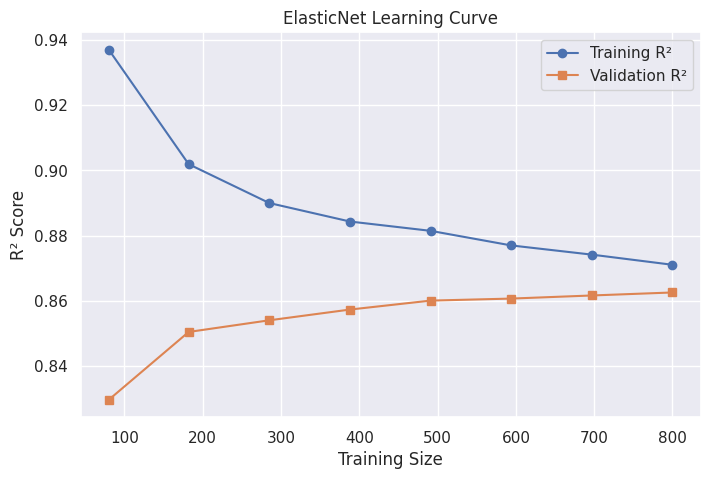

```python
train_sizes, train_scores, val_scores = learning_curve(
    best_model, X_scaled, y, cv=KFold(n_splits=5, shuffle=True, random_state=42),
    scoring="r2", train_sizes=np.linspace(0.1, 1.0, 8), n_jobs=-1
)

train_mean = train_scores.mean(axis=1)
val_mean = val_scores.mean(axis=1)

plt.figure(figsize=(8,5))
plt.plot(train_sizes, train_mean, marker='o', label="Training R²")
plt.plot(train_sizes, val_mean, marker='s', label="Validation R²")
plt.xlabel("Training Size")
plt.ylabel("R² Score")
plt.title(f"{best_model_name} Learning Curve")
plt.legend()
plt.grid(True)
plt.show()
```

## Feature Importance

To understand which factors most influence GPA predictions, we examine model-derived feature importance values.  
For ElasticNet, the magnitude of coefficients reflects each feature’s contribution.

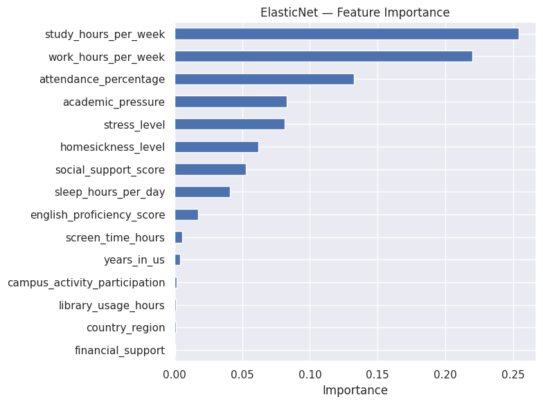

```python
if hasattr(best_model, "coef_"):
    importances = np.abs(best_model.coef_)
elif hasattr(best_model, "feature_importances_"):
    importances = best_model.feature_importances_
else:
    importances = None

if importances is not None:
    fi = pd.Series(importances, index=feature_names).sort_values(ascending=False)
    plt.figure(figsize=(8,6))
    fi.head(15).plot(kind="barh")
    plt.gca().invert_yaxis()
    plt.xlabel("Importance")
    plt.title(f"{best_model_name} — Feature Importance")
    plt.tight_layout()
    plt.show()
    fi
else:
    fi = None
    fi
```

## Saving the Final Model

We save the trained model, scaler, and encoders so the prediction pipeline can be reused without retraining.  
This allows the model to be deployed or used for future GPA predictions.

```python
joblib.dump(best_model, "best_model.pkl")
joblib.dump(scaler, "scaler.pkl")
joblib.dump(encoders, "encoders.pkl")
feature_names
```

```
['gender',
 'parental level of education',
 'age',
 'country_region',
 'years_in_us',
 'family_income_usd',
 'financial_support',
 'work_hours_per_week',
 'scholarship_status',
 'housing_type',
 'study_hours_per_week',
 'attendance_percentage',
 'sleep_hours_per_day',
 'screen_time_hours',
 'campus_activity_participation',
 'library_usage_hours',
 'stress_level',
 'homesickness_level',
 'academic_pressure',
 'social_support_score',
 'visa_type',
 'work_restriction_impact',
 'prev_sem_gpa',
 'english_proficiency_score']
```

## GPA Prediction Function

The function below takes a new student's details as input, applies the saved preprocessing steps, and outputs a predicted semester GPA using the trained model.

```python
def predict_gpa(student_dict):
    df_input = pd.DataFrame([student_dict])

    for col in cat_cols:
        le = encoders[col]
        df_input[col] = le.transform(df_input[col])

    df_input = df_input[feature_names]
    scaled = scaler.transform(df_input)
    pred = best_model.predict(scaled)[0]
    return pred
```

## Sample Student Predictions

Below are example student profiles used to test the prediction pipeline.  
The model processes each profile and generates a predicted semester GPA.

```python
samples = [
    {
        "gender": "male",
        "parental level of education": "master's degree",
        "age": 25,
        "country_region": "China",
        "years_in_us": 3,
        "family_income_usd": 82000,
        "financial_support": "Scholarship",
        "work_hours_per_week": 5,
        "scholarship_status": "Yes",
        "housing_type": "On-campus",
        "study_hours_per_week": 20,
        "attendance_percentage": 95,
        "sleep_hours_per_day": 7,
        "screen_time_hours": 3,
        "campus_activity_participation": 6,
        "library_usage_hours": 8,
        "stress_level": 4,
        "homesickness_level": 2,
        "academic_pressure": 5,
        "social_support_score": 8,
        "visa_type": "F1",
        "work_restriction_impact": 4,
        "prev_sem_gpa": 3.5,
        "english_proficiency_score": 112
    },
    {
        "gender": "female",
        "parental level of education": "associate's degree",
        "age": 21,
        "country_region": "Brazil",
        "years_in_us": 1,
        "family_income_usd": 42000,
        "financial_support": "Loan",
        "work_hours_per_week": 18,
        "scholarship_status": "No",
        "housing_type": "Off-campus",
        "study_hours_per_week": 10,
        "attendance_percentage": 85,
        "sleep_hours_per_day": 6,
        "screen_time_hours": 6,
        "campus_activity_participation": 2,
        "library_usage_hours": 4,
        "stress_level": 7,
        "homesickness_level": 5,
        "academic_pressure": 7,
        "social_support_score": 5,
        "visa_type": "F1",
        "work_restriction_impact": 6,
        "prev_sem_gpa": 2.8,
        "english_proficiency_score": 95
    },
    {
        "gender": "female",
        "parental level of education": "some college",
        "age": 24,
        "country_region": "Germany",
        "years_in_us": 4,
        "family_income_usd": 115000,
        "financial_support": "Self-funded",
        "work_hours_per_week": 0,
        "scholarship_status": "No",
        "housing_type": "With relatives",
        "study_hours_per_week": 25,
        "attendance_percentage": 98,
        "sleep_hours_per_day": 8,
        "screen_time_hours": 2,
        "campus_activity_participation": 5,
        "library_usage_hours": 10,
        "stress_level": 3,
        "homesickness_level": 1,
        "academic_pressure": 4,
        "social_support_score": 9,
        "visa_type": "F1",
        "work_restriction_impact": 2,
        "prev_sem_gpa": 3.8,
        "english_proficiency_score": 118
    }
]

for i, s in enumerate(samples, 1):
    print(f"Student {i} Predicted GPA:", predict_gpa(s))
```

```
Student 1 Predicted GPA: 3.3320009577604126
Student 2 Predicted GPA: 2.2938860705180657
Student 3 Predicted GPA: 3.7607915106158365
```

## Conclusion

In this project, we built a complete machine learning pipeline to predict students’ semester GPA using academic, behavioral, and demographic features. After evaluating multiple regression models through 5-fold cross-validation, **ElasticNet** delivered the best overall performance with a strong balance between accuracy and generalization.

The final model demonstrates reliable predictive performance and provides meaningful insights into the factors associated with student success. The prediction function and saved model components enable future use without retraining.